# rendu_4_Rmarkdown

Benjamin Orlik

26/04/2020

## Installation des library necessaires

```r
library("knitr")
library("rmarkdown")
library("markdown")
library("lubridate")
library("forecast")
library("tidyverse")
```

## Creation d’une serie temporelle de CO2

```r
hawai <- read_csv("data/hawai.csv")
CO2_ts <- ts(c(hawai$CO2), start = c(1958, 3), frequency = 12)
CO2_ts
```

```
##           Jan      Feb      Mar      Apr      May      Jun      Jul      Aug
## 1958                   316.1000 317.2000 317.4333 317.4333 315.6250 314.9500
## 1959 315.5000 316.7000 316.7333 317.6750 318.3250 318.0250 316.5250 314.9000
## 1960 316.3800 316.9750 317.5750 319.1200 319.9250 319.4500 318.0600 315.7750
## 1961 316.9250 317.6500 318.5250 319.4200 320.4750 319.7500 318.3200 316.7750
## 1962 317.9250 318.6250 319.6800 320.5500 320.9000 320.5000 319.4250 317.7333
## 1963 318.7250 318.9667 319.8600 321.2750 322.1000 321.4600 319.6000 317.6000
## 1964 319.4000 319.4000 319.1000 319.4000 322.0000 321.7500 320.3000 318.5000
## 1965 319.4000 320.4500 320.9250 322.0000 322.0600 321.7750 321.0400 318.7250
## 1966 320.5400 321.5750 322.3750 323.6600 324.0250 323.7000 322.8500 320.2000
## 1967 322.4000 322.4250 323.0000 324.2800 324.9500 324.0750 322.4800 320.8500
## 1968 322.5500 323.0500 323.9200 324.9750 325.4750 325.2600 324.0250 321.9400
## 1969 323.9250 324.2750 325.6000 326.5750 327.2800 326.5500 325.8000 323.5400
## 1970 325.0800 326.0250 327.0000 328.0750 327.9200 327.5500 326.3000 324.6600
## 1971 326.1400 326.6500 327.2000 327.6750 328.8200 328.4750 327.2200 325.2500
```

[output cut: 75 more lines]

## Separation en partie d’entrainement et de test

Avec comme objectif, d’obtenir 70 % de donnees d’entrainement, il faut finir en 1989.

```r
hawai_ts_train <- window(CO2_ts, end = c(1989, 12))
hawai_ts_test <- window(CO2_ts, start = c(1990, 1))
```

## Creation d’un modele ETS pour les donnees d’entrainement

```r
hawai_model <- ets(hawai_ts_train)
hawai_model
```

```
## ETS(M,Ad,M)
##
## Call:
##  ets(y = hawai_ts_train)
##
##   Smoothing parameters:
##     alpha = 0.7241
##     beta  = 0.0357
##     gamma = 9e-04
##     phi   = 0.977
##
##   Initial states:
##     l = 314.6622
##     b = 0.1933
##     s = 1.0018 0.9999 0.9971 0.9938 0.9908 0.9913
##            0.9963 1.0023 1.0068 1.0087 1.0072 1.004
##
##   sigma:  0.001
##
##      AIC     AICc      BIC
## 1460.930 1462.814 1531.948
```

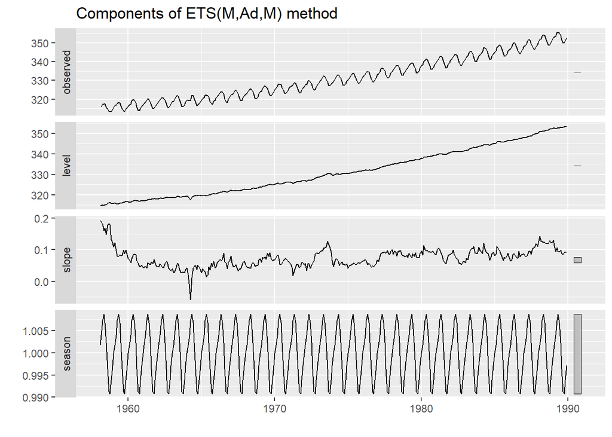

```r
autoplot(hawai_model)
```

On observe une hausse du niveau de CO2 de 1958 à 1990 et on voit égqlement une variation saisonniere du niveau de CO2. (M,Ad,M) signifie que l’erreur est multiplicative, la tendance est presente, et la saison est multiplicative.

## Projection de la prevision de CO2 atmosphérique

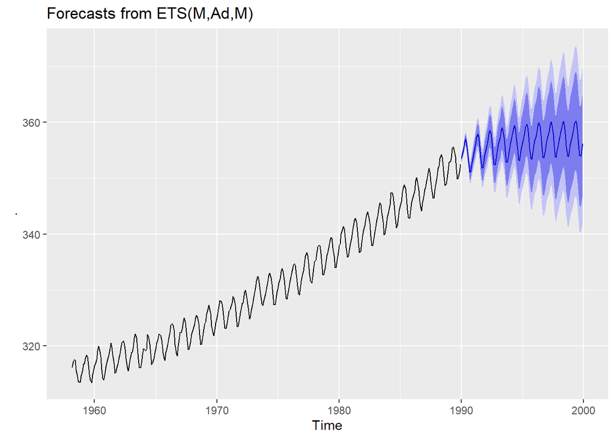

```r
hawai_ets <- hawai_ts_train %>% ets()
hawai_fc <- hawai_ets %>% forecast(h=12*10)
hawai_fc %>% autoplot()
```

```r
summary(hawai_fc)
```

```
##
## Forecast method: ETS(M,Ad,M)
##
## Model Information:
## ETS(M,Ad,M)
##
## Call:
##  ets(y = .)
##
##   Smoothing parameters:
##     alpha = 0.7241
##     beta  = 0.0357
##     gamma = 9e-04
##     phi   = 0.977
##
##   Initial states:
##     l = 314.6622
##     b = 0.1933
##     s = 1.0018 0.9999 0.9971 0.9938 0.9908 0.9913
##            0.9963 1.0023 1.0068 1.0087 1.0072 1.004
##
##   sigma:  0.001
##
##      AIC     AICc      BIC
## 1460.930 1462.814 1531.948
##
## Error measures:
##                      ME      RMSE       MAE        MPE       MAPE      MASE
## Training set 0.04041742 0.3272724 0.2470216 0.01192918 0.07491171 0.2002344
##                     ACF1
## Training set -0.04225915
##
## Forecasts:
##          Point Forecast    Lo 80    Hi 80    Lo 95    Hi 95
## Jan 1990       353.5520 353.0893 354.0147 352.8444 354.2597
## Feb 1990       354.2996 353.7173 354.8818 353.4091 355.1901
## Mar 1990       355.1723 354.4816 355.8629 354.1160 356.2285
## Apr 1990       356.4088 355.6154 357.2022 355.1954 357.6222
## May 1990       357.0028 356.1120 357.8936 355.6405 358.3651
## Jun 1990       356.4228 355.4407 357.4049 354.9208 357.9248
```

[output cut: 99 more lines]

```
## Oct 1998       353.8576 345.5980 362.1172 341.2256 366.4896
## Nov 1998       354.9611 346.6165 363.3056 342.1992 367.7230
## Dec 1998       356.1278 347.6967 364.5589 343.2335 369.0221
## Jan 1999       357.1413 348.6271 365.6555 344.1199 370.1627
## Feb 1999       357.8127 349.2236 366.4019 344.6768 370.9487
## Mar 1999       358.6122 349.9451 367.2793 345.3569 371.8674
## Apr 1999       359.7804 351.0263 368.5346 346.3922 373.1687
## May 1999       360.3015 351.4761 369.1270 346.8042 373.7988
## Jun 1999       359.6396 350.7722 368.5071 346.0780 373.2012
## Jul 1999       358.0322 349.1466 366.9177 344.4429 371.6215
## Aug 1999       355.9140 347.0238 364.8042 342.3177 369.5104
## Sep 1999       354.1111 345.2094 363.0129 340.4970 367.7253
## Oct 1999       353.9394 344.9855 362.8933 340.2456 367.6332
## Nov 1999       355.0412 346.0032 364.0793 341.2187 368.8638
## Dec 1999       356.2064 347.0823 365.3304 342.2524 370.1604
```

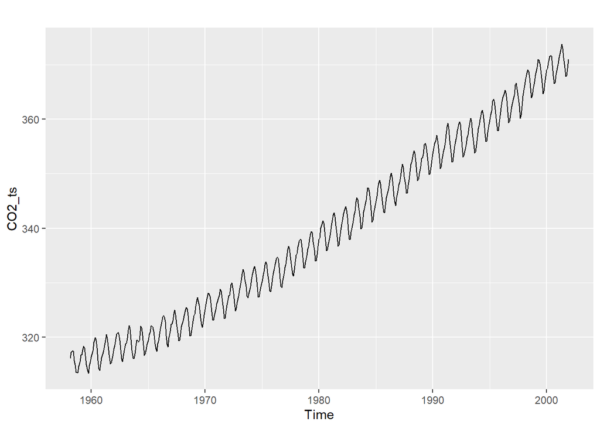

```r
autoplot(CO2_ts)
```

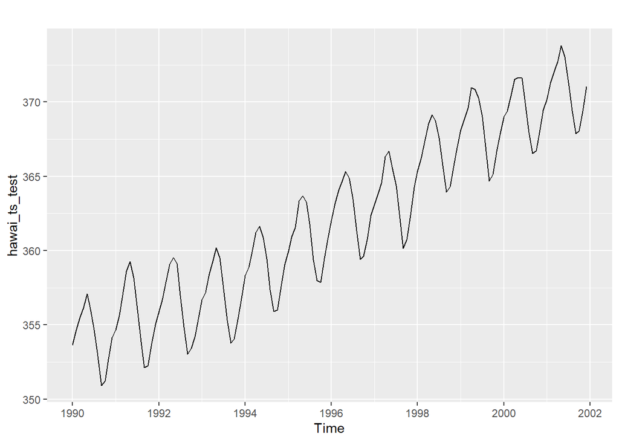

```r
autoplot(hawai_ts_test)
```

Par comparaison, on peut voir que la prediction de l’ETS semble bonne pour la variation saisonniere. En revanche, on remarque globalement que les predictions sont en dessous de la realite.

# On peut aussi vérifier la précision de la prevision :

```r
accuracy(hawai_fc, CO2_ts)
```

```
##                      ME      RMSE       MAE        MPE       MAPE      MASE
## Training set 0.04041742 0.3272724 0.2470216 0.01192918 0.07491171 0.2002344
## Test set     4.22348515 5.6339180 4.2405294 1.15932558 1.16413107 3.4373506
##                     ACF1 Theil's U
## Training set -0.04225915        NA
## Test set      0.97438878  4.319808
```

## Analyse des residus

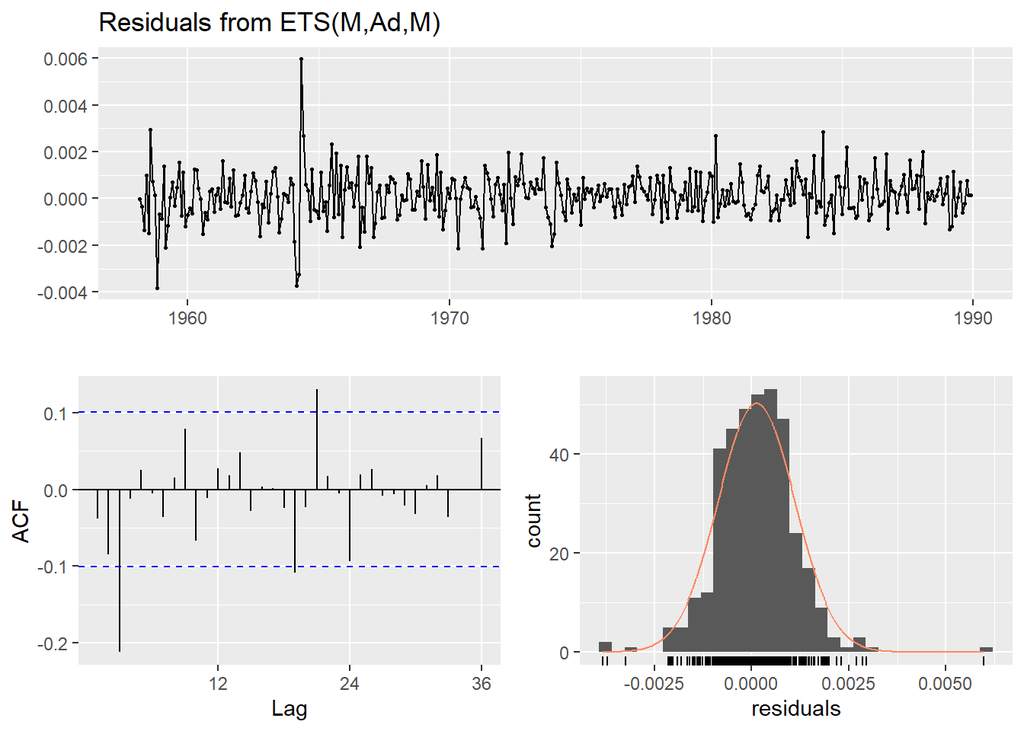

```
##
##  Ljung-Box test
##
## data:  Residuals from ETS(M,Ad,M)
## Q* = 43.204, df = 7, p-value = 3.046e-07
##
## Model df: 17.   Total lags used: 24
```

```r
checkresiduals(hawai_ets)
```

On observe dans le graphique “Lag” que certaines données dépassent le seuil de confiance d’autocorrélation. Il existe donc une corrélation signidicative dans les données. Enfin, le graphique “residuals” semble graphiquement suivre une loi normale.

# Test de Shapiro

Pour verifier la normalité, on effectue un test de Shapiro :

```r
hawai_residu <- residuals(hawai_ets)
shapiro.test(hawai_residu)
```

```
##
##  Shapiro-Wilk normality test
##
## data:  hawai_residu
## W = 0.96424, p-value = 4.846e-08
```

On obtient une p-value proche de zero, donc significative. Cela signifit que l’echantillon ne suis donc pas une loi normale.

## Amelioration du modele

On peut aussi ameliorer le modele pour obtenir une meilleure prediction en effetuant un pretraitement. On peut par exemple optimiser la valeur lambda :

```r
BoxCox.lambda(hawai_ts_train)
```

```
## [1] 0.1127346
```

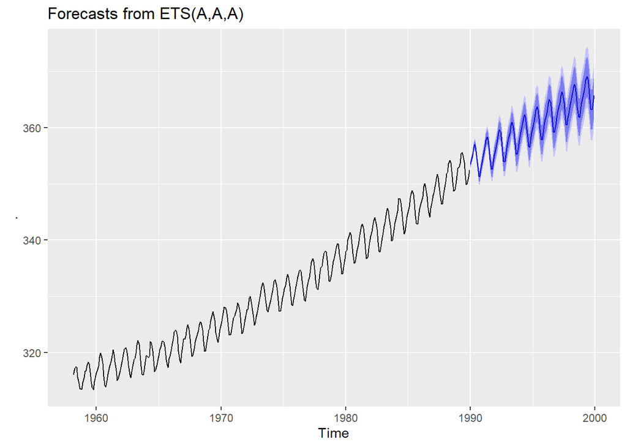

```r
hawai_ets <- hawai_ts_train %>% ets(lambda = 0.1127)
hawai_fc <- hawai_ets %>% forecast(h=12*10)
hawai_fc %>% autoplot()
```

```r
summary(hawai_fc)
```

```
##
## Forecast method: ETS(A,A,A)
##
## Model Information:
## ETS(A,A,A)
##
## Call:
##  ets(y = ., lambda = 0.1127)
##
##   Box-Cox transformation: lambda= 0.1127
##
##   Smoothing parameters:
##     alpha = 0.6367
##     beta  = 0.0014
##     gamma = 1e-04
##
##   Initial states:
##     l = 8.0938
##     b = 6e-04
##     s = 0.0032 -3e-04 -0.0055 -0.0117 -0.0178 -0.0167
##            -0.0068 0.0046 0.0132 0.0165 0.0138 0.0075
##
##   sigma:  0.0019
##
##       AIC      AICc       BIC
## -2496.416 -2494.735 -2429.344
##
## Error measures:
##                       ME     RMSE       MAE         MPE       MAPE      MASE
## Training set 0.009403601 0.318323 0.2403772 0.002424303 0.07290936 0.1948485
##                    ACF1
## Training set 0.03741917
##
## Forecasts:
##          Point Forecast    Lo 80    Hi 80    Lo 95    Hi 95
## Jan 1990       353.5080 353.0628 353.9536 352.8273 354.1898
## Feb 1990       354.2646 353.7356 354.7943 353.4558 355.0750
## Mar 1990       355.1551 354.5528 355.7583 354.2344 356.0780
## Apr 1990       356.4148 355.7459 357.0848 355.3922 357.4400
## May 1990       357.0352 356.3059 357.7658 355.9204 358.1531
```

[output cut: 100 more lines]

```
## Oct 1998       361.8356 358.5116 365.1869 356.7630 366.9721
## Nov 1998       363.0771 359.7243 366.4576 357.9606 368.2585
## Dec 1998       364.3620 360.9799 367.7721 359.2008 369.5888
## Jan 1999       365.4369 362.0272 368.8750 360.2337 370.7066
## Feb 1999       366.2161 362.7813 369.6798 360.9746 371.5251
## Mar 1999       367.1332 363.6720 370.6237 361.8515 372.4833
## Apr 1999       368.4305 364.9397 371.9509 363.1037 373.8266
## May 1999       369.0695 365.5545 372.6144 363.7059 374.5031
## Jun 1999       368.5518 365.0226 372.1113 363.1665 374.0079
## Jul 1999       367.0300 363.4951 370.5953 361.6361 372.4951
## Aug 1999       364.9984 361.4625 368.5650 359.6030 370.4656
## Sep 1999       363.2639 359.7245 366.8341 357.8633 368.7367
## Oct 1999       363.1710 359.6142 366.7590 357.7438 368.6711
## Nov 1999       364.4166 360.8306 368.0342 358.9450 369.9621
## Dec 1999       365.7057 362.0901 369.3533 360.1889 371.2973
```

Le resultat semble bien meilleur. On peut observer une forte diminution de la variabilite du modele (partie bleue)